# act_report

Ryan Mezera

November 16, 2018

# Act Report

### The Data

Data from WeRateDogs twitter was gathered from 3 different sources and combined into one file which we will use for analysis. The process for gathering the data and some general info is as follows:

1. The first data set was provided by Udacity and manually downloaded. This file contained tweet id’s, tweet text, dog ratings, dog names, dog stages, and other data that will not be used at this time.
2. The second data set was programatically downloaded from a URL provided by Udacity. The file contained tweet id’s, image URL’s, and 3 image recognition predictions with probabilities. The URL is as follows: https://d17h27t6h515a5.cloudfront.net/topher/2017/August/599fd2ad_image-predictions/image-predictions.tsv
3. The third data set was pulled from the twitter archive of WeRateDogs using Python’s Tweepy library and tweet id’s. The JSON data for each tweet was pulled and tweet id, retweet count, favorite count, and possible sensitivity status was scraped from the JSON data.

The 3 data sets were combined by matching tweet id’s and will be used for the following analysis.

### Analysis

For data analysis we will focus on ratings, retweets, and favorite counts as metrics. We want to see if user rating correlate with retweets and/or favorite counts. We also want to evaluate dog stages to see if it effects user ratings, retweets and/or favorite counts.

#### Univariate analysis

We will focus our analysis on user ratings, retweet counts, favorite counts, and dog stage.

##### User Rating

```
##    Min. 1st Qu.  Median    Mean 3rd Qu.    Max.
##    0.00    1.00    1.10    1.17    1.20  177.60
```

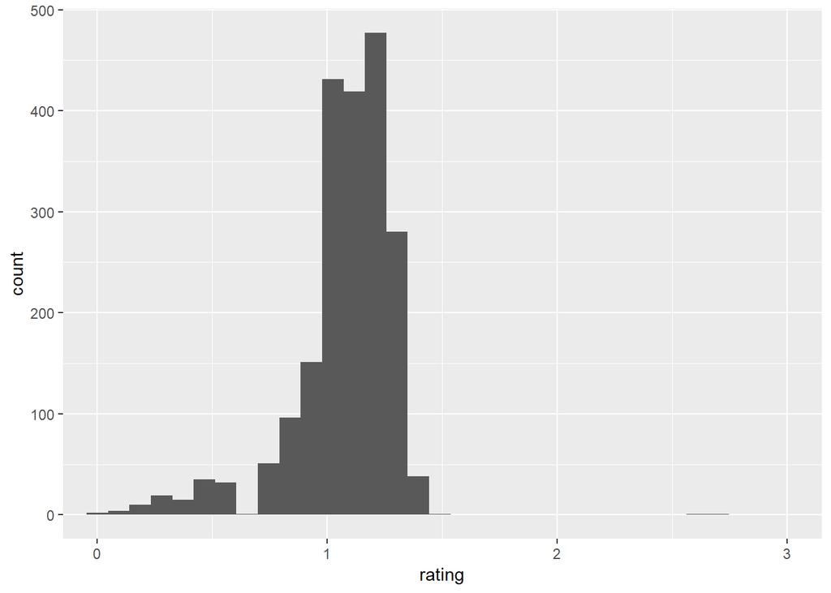

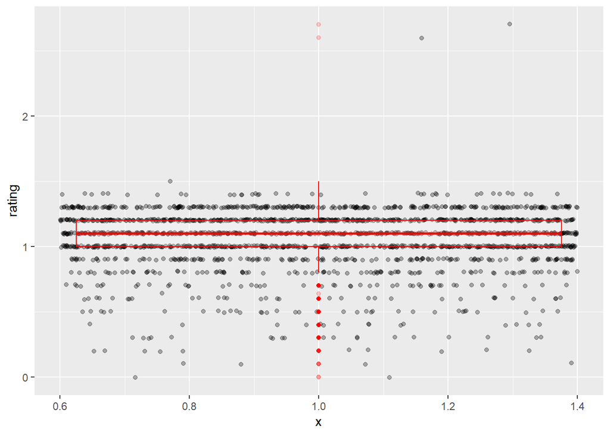

Here we can see user ratings are mostly around 1.10. There are a few outliers as high as 177.6, but most of the ratings are 1 or above.

##### Retweet Count

```
##    Min. 1st Qu.  Median    Mean 3rd Qu.    Max.
##    12.0   600.5  1328.5  2821.7  3258.2 84121.0
```

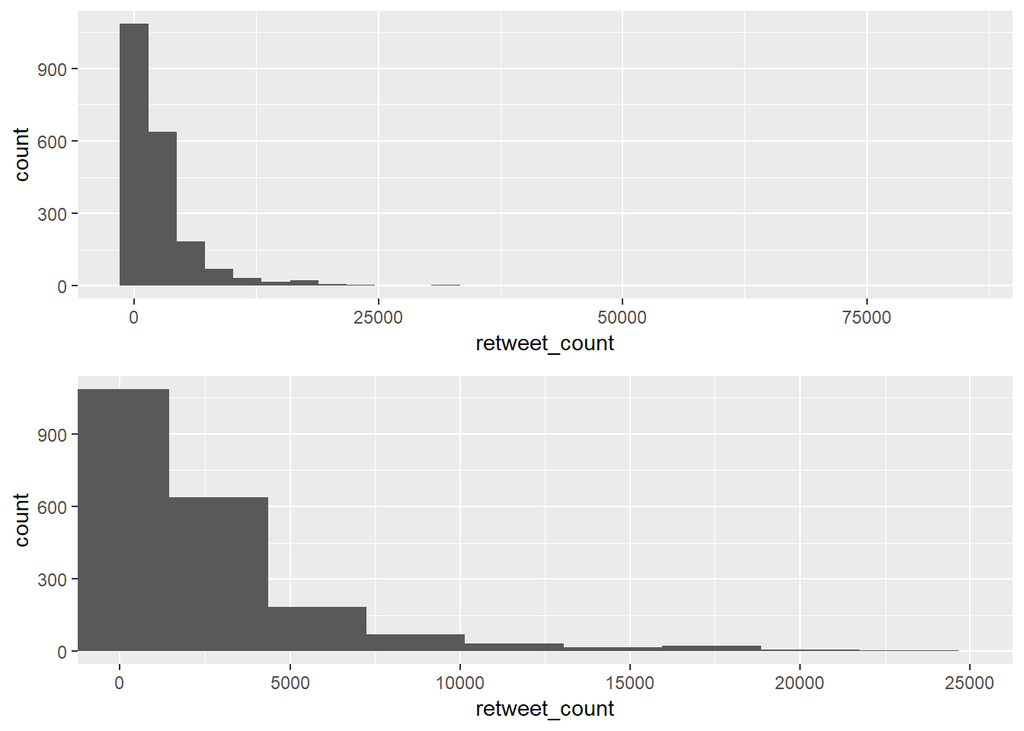

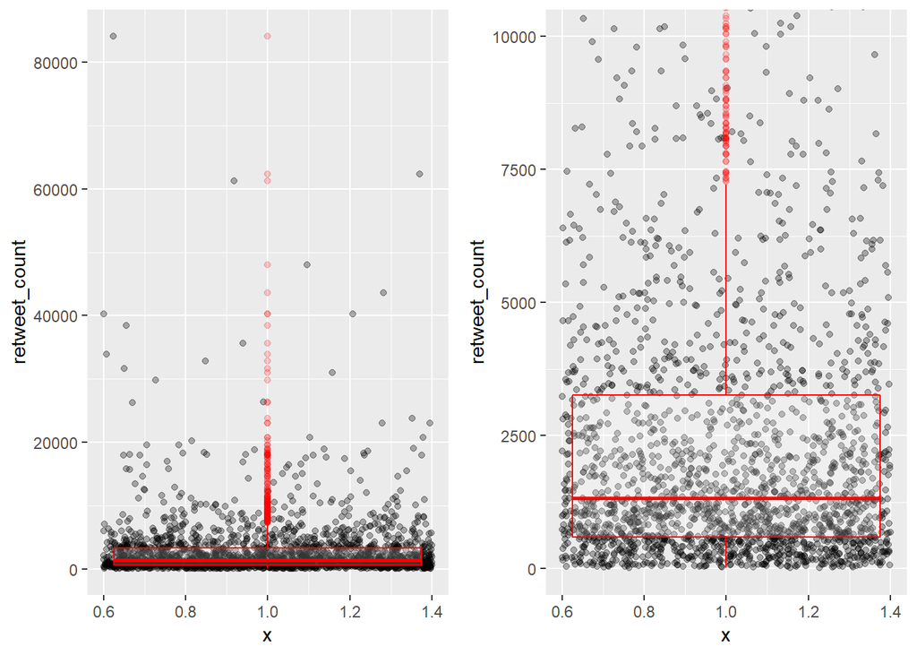

##### Favorite count

```
##    Min. 1st Qu.  Median    Mean 3rd Qu.    Max.
##       0    1610    3727    8458   10598  164928
```

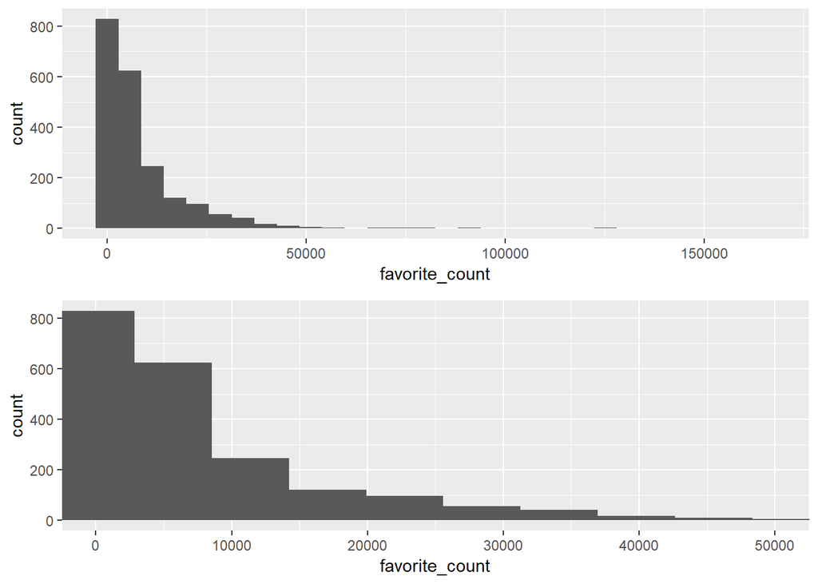

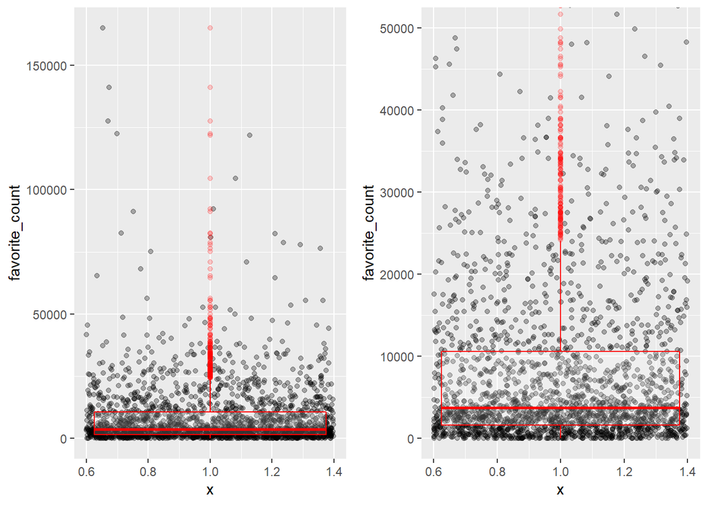

Favorite counts are very similar to retweet counts in how they are distibuted, but favorite counts and retweet counts are different in scale. People tend to favorite a tweet more than they retweet it. The histogram is also skewed right with most of the favorite counts on the lower end.

##### Dog stage

```
##
##        doggo doggofloofer  doggopupper   doggopuppo      floofer
##           67            1           11            1            7
##         None       pupper        puppo
##         1747          211           23
```

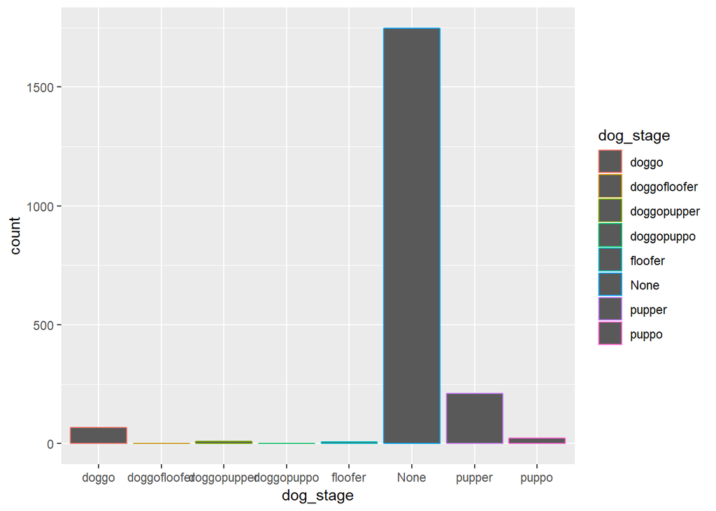

For a large majority of the tweets the dog stage is not categorized. A number of tweets used two or more dog stages to categorize the dogs. The most popular dog stages were pupper and doggo.

#### Bivariate Analysis

###### User rating

```
##
##  Pearson's product-moment correlation
##
## data:  df$rating and df$retweet_count
## t = 0.99595, df = 2066, p-value = 0.3194
## alternative hypothesis: true correlation is not equal to 0
## 95 percent confidence interval:
##  -0.02121796  0.06494901
## sample estimates:
##       cor
## 0.0219062
```

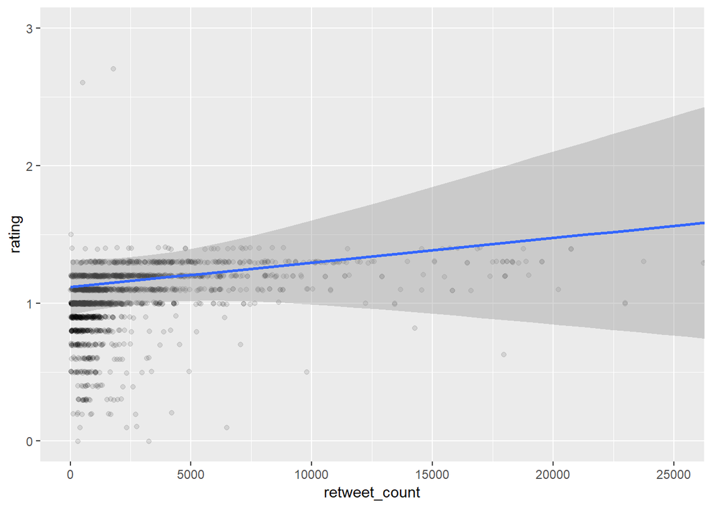

```
##
##  Pearson's product-moment correlation
##
## data:  df$rating and df$favorite_count
## t = 0.97277, df = 2066, p-value = 0.3308
## alternative hypothesis: true correlation is not equal to 0
## 95 percent confidence interval:
##  -0.02172756  0.06444130
## sample estimates:
##        cor
## 0.02139661
```

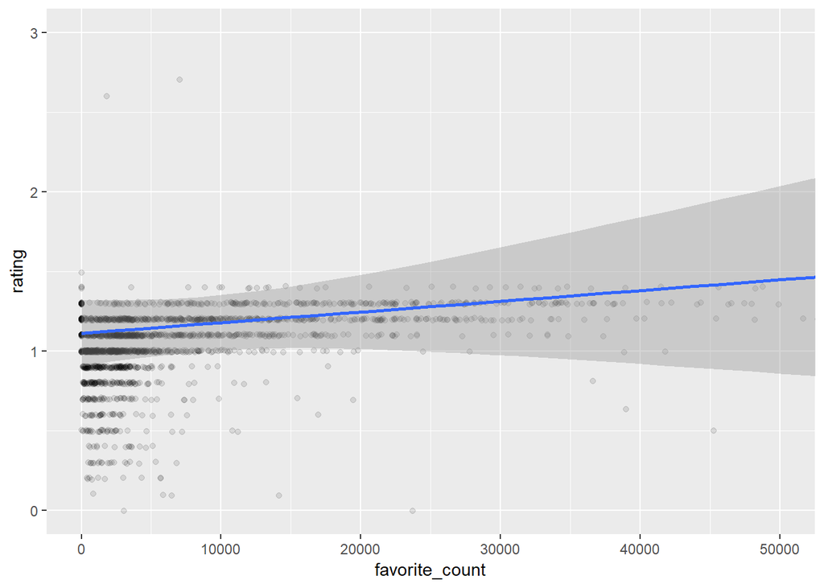

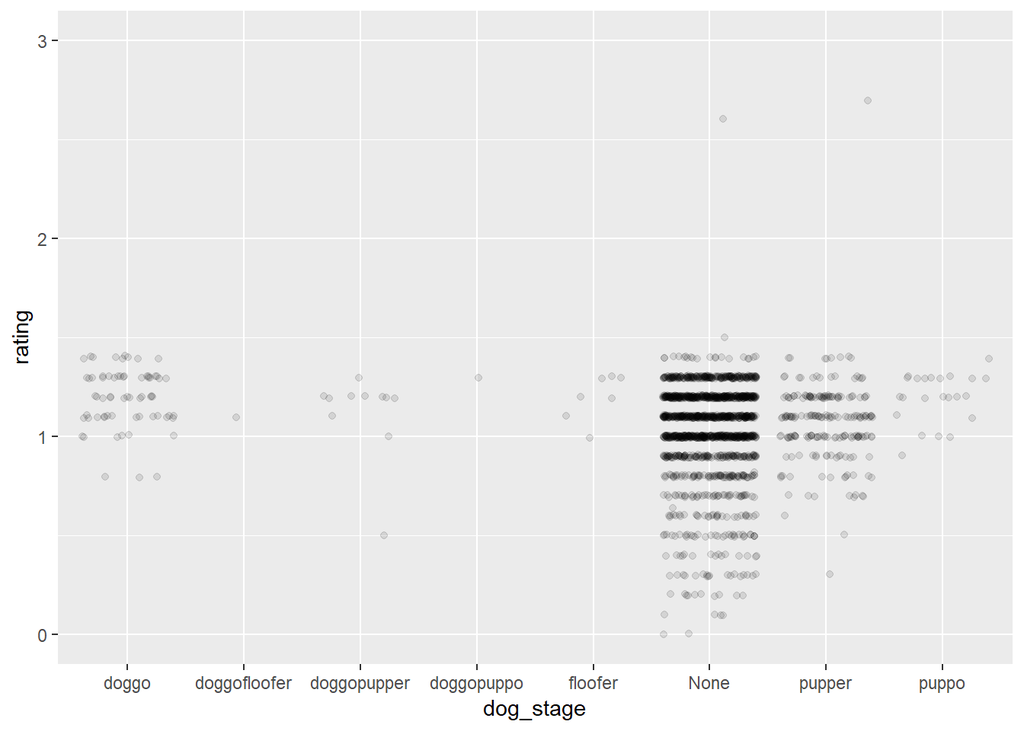

- User ratings did not significantly correlate with retweet_count or favorite_count, both had p-values > 0.05. Dog stage did not appear to have any meaningful effect on user ratings either.

#### Dog stage

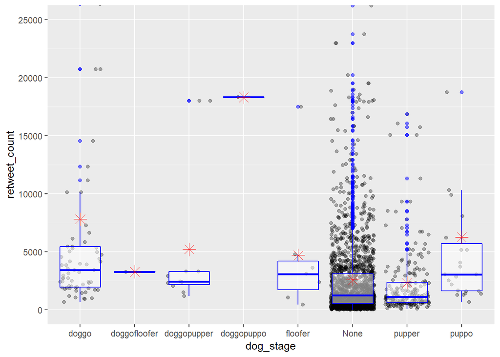

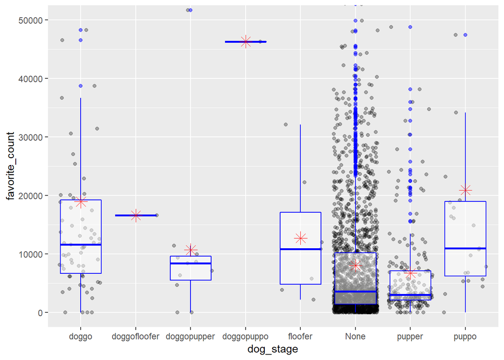

#### Retweet and Favorite counts

```
##
##  Pearson's product-moment correlation
##
## data:  df$retweet_count and df$favorite_count
## t = 75.543, df = 2066, p-value < 2.2e-16
## alternative hypothesis: true correlation is not equal to 0
## 95 percent confidence interval:
##  0.8449583 0.8679037
## sample estimates:
##       cor
## 0.8568547
```

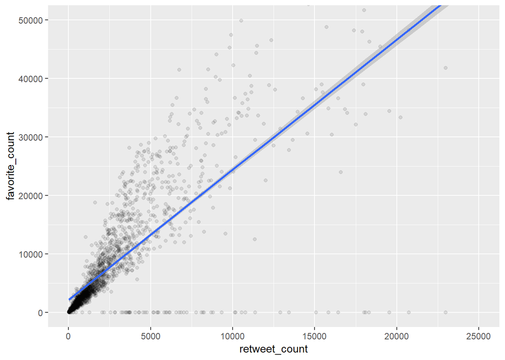

Retweet and favorite counts are significant for correlation with w p-value < 2.2e-16.

### Elapsed time

```
##
##  Pearson's product-moment correlation
##
## data:  df$elapsed_days_y and df$favorite_count
## t = 31.634, df = 2066, p-value < 2.2e-16
## alternative hypothesis: true correlation is not equal to 0
## 95 percent confidence interval:
##  0.5414669 0.5995795
## sample estimates:
##       cor
## 0.5712387
```

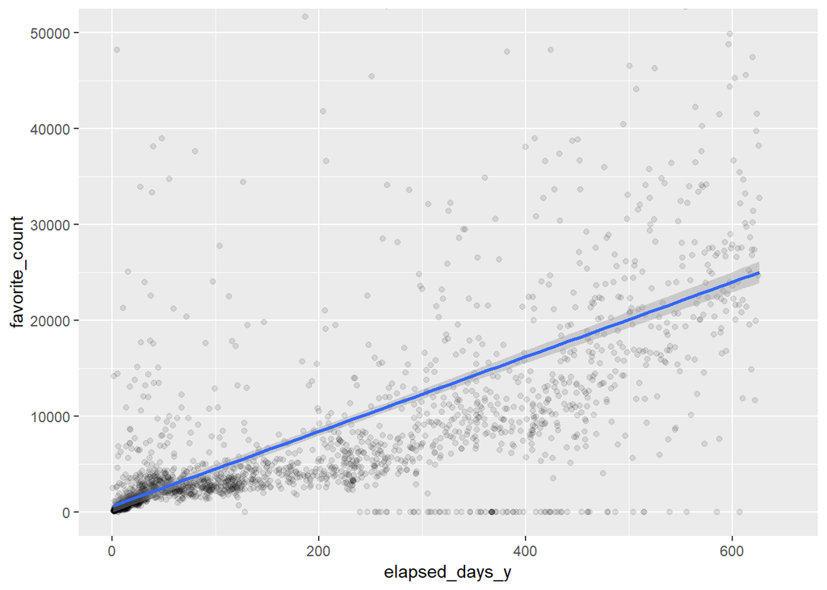

```
##
##  Pearson's product-moment correlation
##
## data:  df$elapsed_days_y and df$retweet_count
## t = 19.083, df = 2066, p-value < 2.2e-16
## alternative hypothesis: true correlation is not equal to 0
## 95 percent confidence interval:
##  0.3498365 0.4231469
## sample estimates:
##       cor
## 0.3871033
```

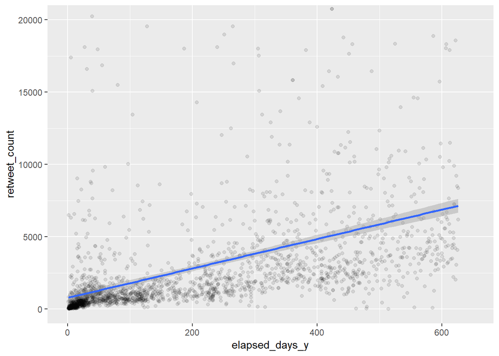

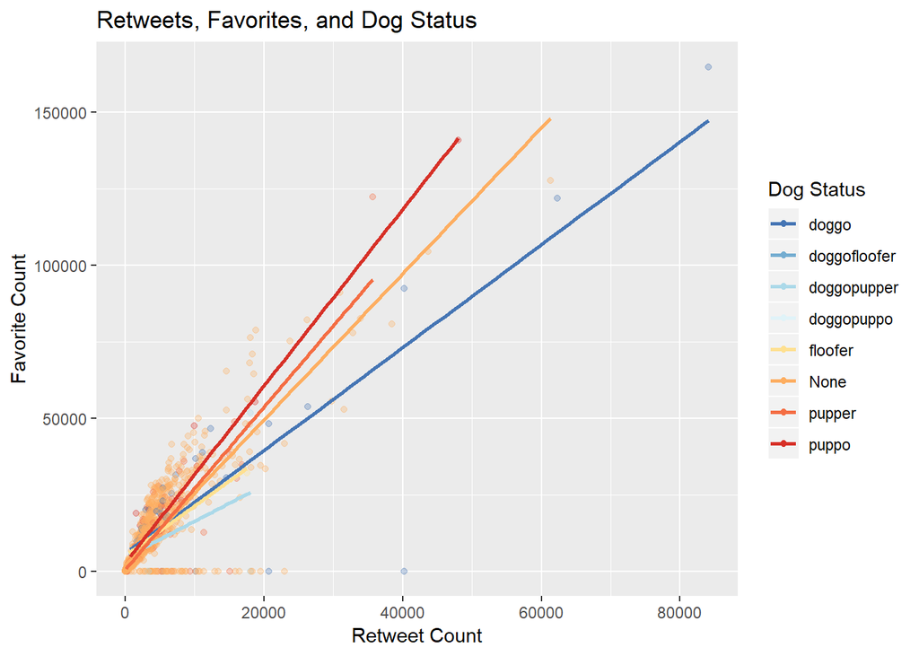